# Final Report

Duc Nguyen

2024-11-24

## House Sales in King County, USA

#### Load the dataset

```r
library(readxl)
data <- read.csv("D:/UCF Grad/Data Preparation/kc_house_data.csv")
```

#### Load libraries

```r
library(dplyr)
library(tidyr)
library(caret)
```

```r
library(corrplot)
library(leaflet)
```

#### EDA

```r
head(data)
```

```
##           id            date   price bedrooms bathrooms sqft_living sqft_lot
## 1 7129300520 20141013T000000  221900        3      1.00        1180     5650
## 2 6414100192 20141209T000000  538000        3      2.25        2570     7242
## 3 5631500400 20150225T000000  180000        2      1.00         770    10000
## 4 2487200875 20141209T000000  604000        4      3.00        1960     5000
## 5 1954400510 20150218T000000  510000        3      2.00        1680     8080
## 6 7237550310 20140512T000000 1225000        4      4.50        5420   101930
##   floors waterfront view condition grade sqft_above sqft_basement yr_built
## 1      1          0    0         3     7       1180             0     1955
## 2      2          0    0         3     7       2170           400     1951
## 3      1          0    0         3     6        770             0     1933
## 4      1          0    0         5     7       1050           910     1965
## 5      1          0    0         3     8       1680             0     1987
## 6      1          0    0         3    11       3890          1530     2001
##   yr_renovated zipcode     lat     long sqft_living15 sqft_lot15
## 1            0   98178 47.5112 -122.257          1340       5650
## 2         1991   98125 47.7210 -122.319          1690       7639
## 3            0   98028 47.7379 -122.233          2720       8062
## 4            0   98136 47.5208 -122.393          1360       5000
## 5            0   98074 47.6168 -122.045          1800       7503
## 6            0   98053 47.6561 -122.005          4760     101930
```

```r
summary(data)
```

```
##        id                date               price            bedrooms
##  Min.   :1.000e+06   Length:21613       Min.   :  75000   Min.   : 0.000
##  1st Qu.:2.123e+09   Class :character   1st Qu.: 321950   1st Qu.: 3.000
##  Median :3.905e+09   Mode  :character   Median : 450000   Median : 3.000
##  Mean   :4.580e+09                      Mean   : 540088   Mean   : 3.371
##  3rd Qu.:7.309e+09                      3rd Qu.: 645000   3rd Qu.: 4.000
##  Max.   :9.900e+09                      Max.   :7700000   Max.   :33.000
##    bathrooms      sqft_living       sqft_lot           floors
##  Min.   :0.000   Min.   :  290   Min.   :    520   Min.   :1.000
##  1st Qu.:1.750   1st Qu.: 1427   1st Qu.:   5040   1st Qu.:1.000
##  Median :2.250   Median : 1910   Median :   7618   Median :1.500
##  Mean   :2.115   Mean   : 2080   Mean   :  15107   Mean   :1.494
##  3rd Qu.:2.500   3rd Qu.: 2550   3rd Qu.:  10688   3rd Qu.:2.000
##  Max.   :8.000   Max.   :13540   Max.   :1651359   Max.   :3.500
##    waterfront            view          condition         grade
##  Min.   :0.000000   Min.   :0.0000   Min.   :1.000   Min.   : 1.000
##  1st Qu.:0.000000   1st Qu.:0.0000   1st Qu.:3.000   1st Qu.: 7.000
##  Median :0.000000   Median :0.0000   Median :3.000   Median : 7.000
##  Mean   :0.007542   Mean   :0.2343   Mean   :3.409   Mean   : 7.657
##  3rd Qu.:0.000000   3rd Qu.:0.0000   3rd Qu.:4.000   3rd Qu.: 8.000
##  Max.   :1.000000   Max.   :4.0000   Max.   :5.000   Max.   :13.000
##    sqft_above   sqft_basement       yr_built     yr_renovated
##  Min.   : 290   Min.   :   0.0   Min.   :1900   Min.   :   0.0
##  1st Qu.:1190   1st Qu.:   0.0   1st Qu.:1951   1st Qu.:   0.0
##  Median :1560   Median :   0.0   Median :1975   Median :   0.0
##  Mean   :1788   Mean   : 291.5   Mean   :1971   Mean   :  84.4
##  3rd Qu.:2210   3rd Qu.: 560.0   3rd Qu.:1997   3rd Qu.:   0.0
##  Max.   :9410   Max.   :4820.0   Max.   :2015   Max.   :2015.0
##     zipcode           lat             long        sqft_living15
##  Min.   :98001   Min.   :47.16   Min.   :-122.5   Min.   : 399
##  1st Qu.:98033   1st Qu.:47.47   1st Qu.:-122.3   1st Qu.:1490
##  Median :98065   Median :47.57   Median :-122.2   Median :1840
##  Mean   :98078   Mean   :47.56   Mean   :-122.2   Mean   :1987
##  3rd Qu.:98118   3rd Qu.:47.68   3rd Qu.:-122.1   3rd Qu.:2360
##  Max.   :98199   Max.   :47.78   Max.   :-121.3   Max.   :6210
##    sqft_lot15
##  Min.   :   651
##  1st Qu.:  5100
##  Median :  7620
##  Mean   : 12768
##  3rd Qu.: 10083
##  Max.   :871200
```

```r
# Drop id, date columns
data <- data %>% select(-id)
data <- data %>% select(-date)
```

```r
data <- data %>% drop_na()  # Removes rows with any NA values
data <- data %>% distinct() # Remove duplicate rows
```

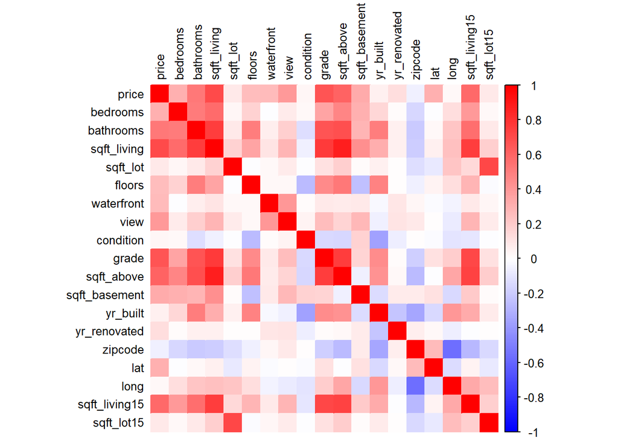

```r
# Compute the correlation matrix
cor_matrix <- cor(data)

# Plot the correlation heatmap
corrplot(cor_matrix, method = "color", col = colorRampPalette(c("blue", "white", "red"))(200),
         tl.col = "black", tl.cex = 0.8)
```

The features sqft_living, sqft_above, grade, and sqft_living15 show the strongest positive correlations with price. This indicates that as these features increase, the house price tends to increase as well.

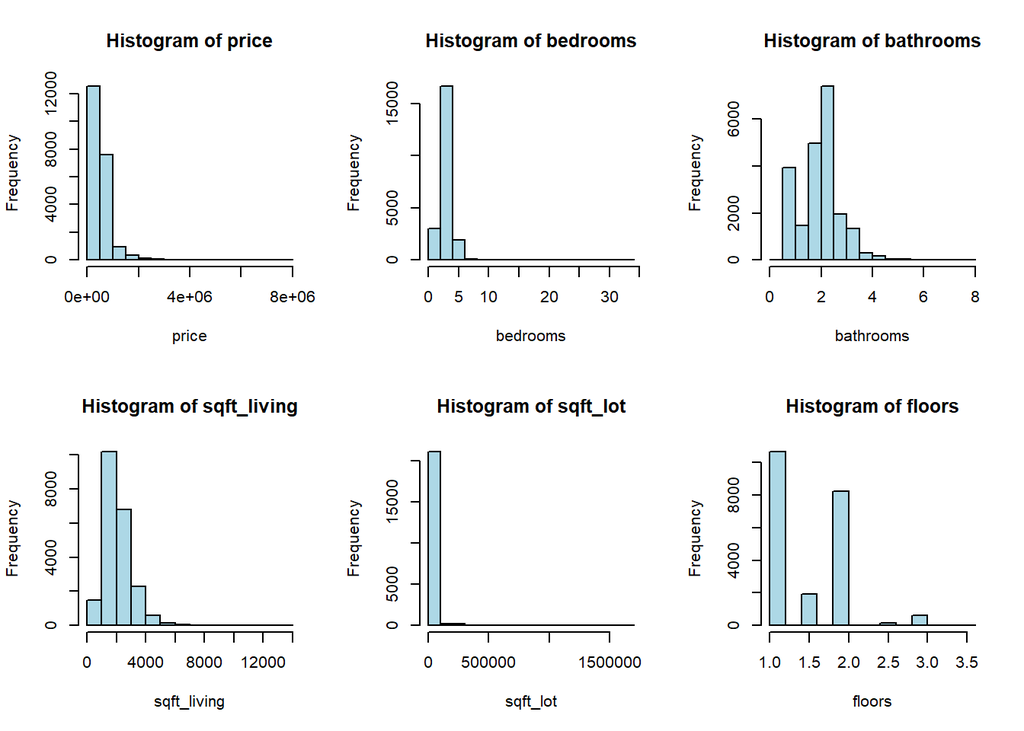

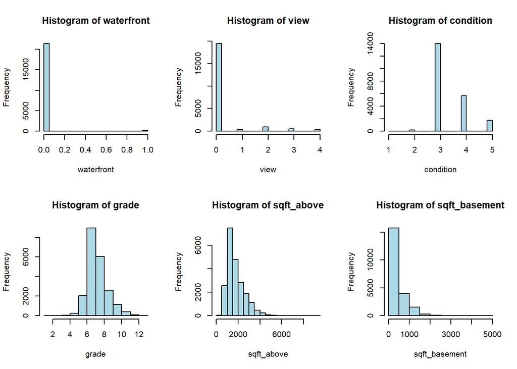

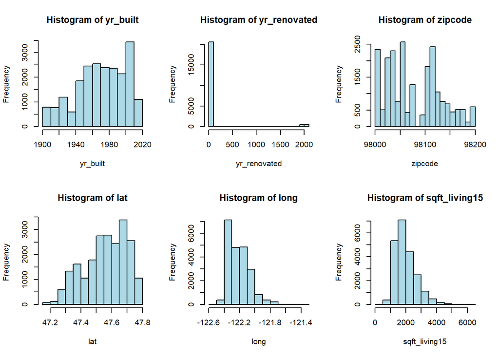

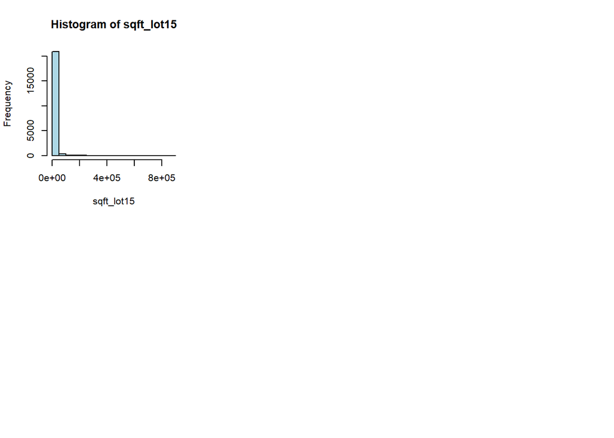

```r
par(mfrow=c(2, 3))  # Arrange plots in a 2x3 grid
for (col in names(data)) {
  hist(data[[col]], main=paste("Histogram of", col), xlab=col, col="lightblue")
}
```

During the EDA, I found that the target variable, `price`, was highly right-skewed due to outliers. To prevent these outliers from affecting model performance, I decided to remove rows containing extreme values in the target variable.

#### Data Preprocessing

```r
# Calculate the IQR for the price column
Q1 <- quantile(data$price, 0.25, na.rm = TRUE)
Q3 <- quantile(data$price, 0.75, na.rm = TRUE)
IQR_value <- Q3 - Q1

# Define the lower and upper bounds for outliers
lower_bound <- Q1 - 1.5 * IQR_value
upper_bound <- Q3 + 1.5 * IQR_value

# Remove rows where the price is outside of the bounds
clean_data <- data[data$price >= lower_bound & data$price <= upper_bound, ]
```

Outliers can distort model training, especially for algorithms like k-NN, which are sensitive to data scale. By removing them, the model can better focus on typical data points and avoid overfitting.

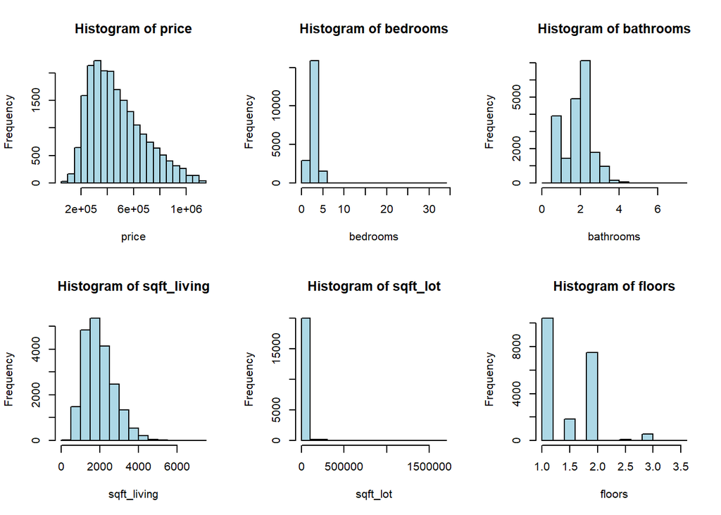

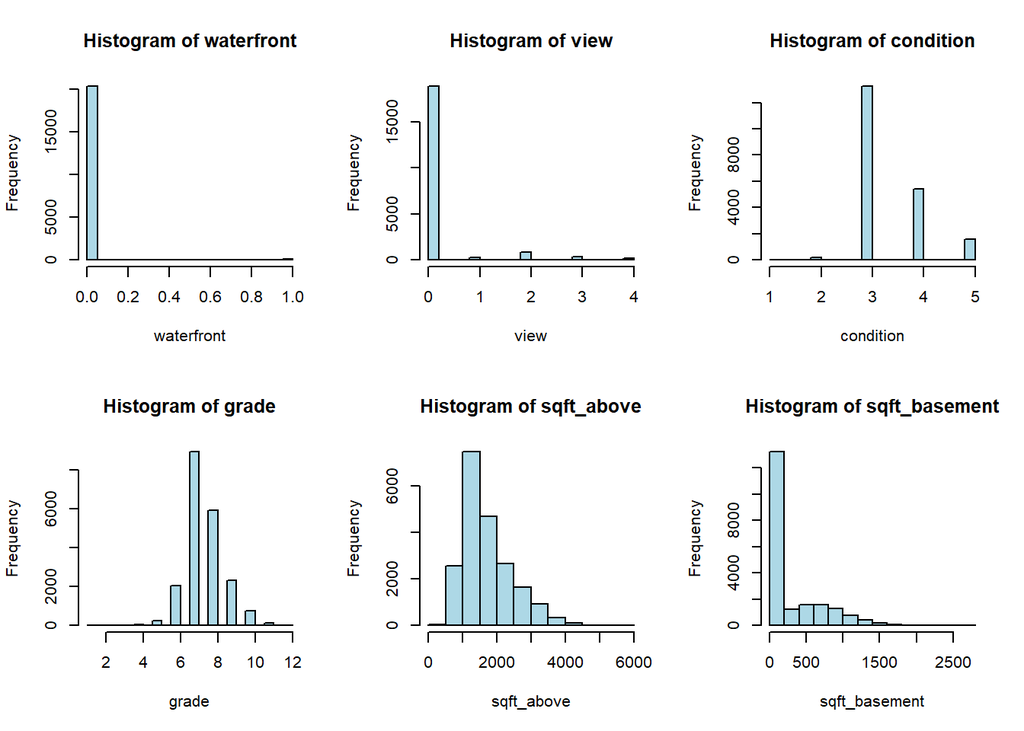

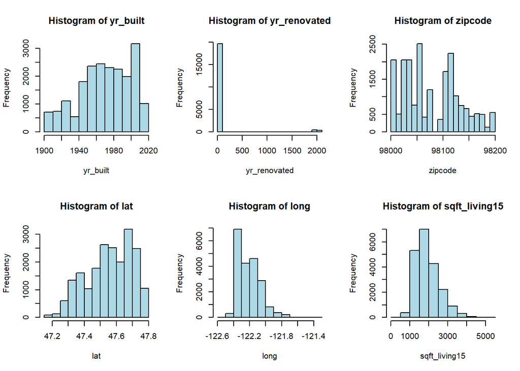

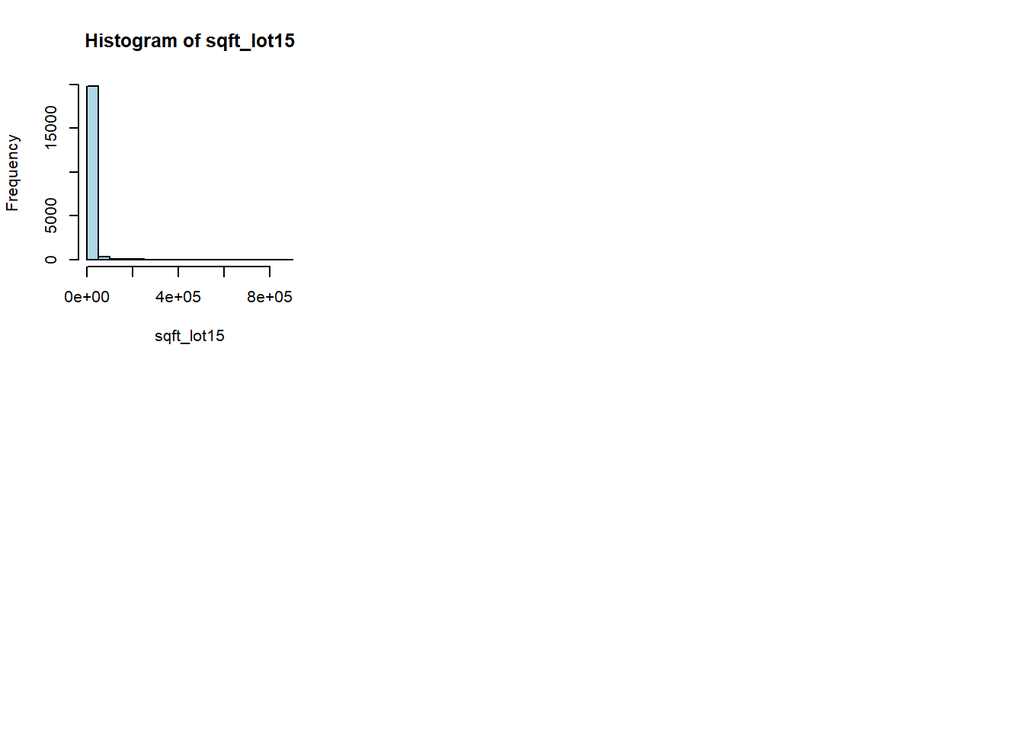

```r
par(mfrow=c(2, 3))  # Arrange plots in a 2x3 grid
for (col in names(clean_data)) {
  hist(clean_data[[col]], main=paste("Histogram of", col), xlab=col, col="lightblue")
}
```

After removing the outliers in the target variable (price), the distribution became more centered, indicating a more normal-like spread of values.

### Data Preparation

```r
set.seed(123)

# Due to technical issue, I had to narrow down the dataset to 5000 rows so my laptop can run it
subset_data <- clean_data[sample(nrow(clean_data), 5000), ]
```

```r
set.seed(123)
idx <- createDataPartition(subset_data$price, p = 0.7, list = FALSE)
train.df <- subset_data[idx, ]
test.df <- subset_data[-idx, ]
```

### Model Implementation and Evaluation

#### KNN

```r
set.seed(123)
preproc <- preProcess(train.df[,-1], method = c("center", "scale"))
train_scaled <- predict(preproc, train.df[,-1])
test_scaled <- predict(preproc, test.df[,-1])
train_scaled <- bind_cols(price = train.df$price, train_scaled)
test_scaled <- bind_cols(price = test.df$price, test_scaled)
trControl <- trainControl(method = "repeatedcv", number = 5, repeats = 3)
model <- train(price ~., data=train_scaled,method="knn",preProcess=c("center", "scale"),tuneGrid=expand.grid(k=seq(1, 20, 1)),trControl=trControl)
model
```

```
## k-Nearest Neighbors
##
## 3503 samples
##   18 predictor
##
## Pre-processing: centered (18), scaled (18)
## Resampling: Cross-Validated (5 fold, repeated 3 times)
## Summary of sample sizes: 2803, 2802, 2802, 2802, 2803, 2802, ...
## Resampling results across tuning parameters:
##
##   k   RMSE      Rsquared   MAE
##    1  131714.3  0.6276771  92121.20
##    2  115278.1  0.6947340  82194.07
##    3  109708.3  0.7198816  78361.14
##    4  108170.9  0.7269570  77368.16
##    5  106741.6  0.7340755  76398.05
##    6  105864.8  0.7389690  75876.52
##    7  105559.3  0.7410846  75488.99
##    8  105673.9  0.7413049  75625.80
##    9  105832.3  0.7412432  75728.30
##   10  106069.3  0.7408923  75995.83
##   11  106510.8  0.7394338  76326.88
##   12  106463.4  0.7404625  76339.61
##   13  106444.5  0.7413033  76410.33
##   14  106627.4  0.7410312  76545.93
##   15  106779.0  0.7409119  76721.67
##   16  107105.4  0.7397192  76904.57
##   17  107286.5  0.7395299  77060.91
##   18  107761.2  0.7375649  77420.58
##   19  107990.8  0.7369804  77563.52
##   20  108147.9  0.7369948  77754.12
##
## RMSE was used to select the optimal model using the smallest value.
## The final value used for the model was k = 7.
```

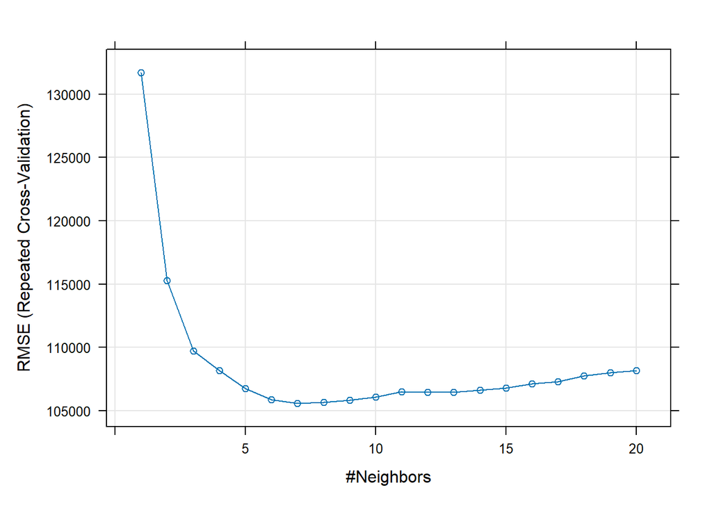

```r
plot(model)
```

Based on the results, k=7 yields the lowest RMSE, indicating the best performance for this dataset.

```r
set.seed(123)
final_knn_model <- train(
  price ~ .,
  data = train_scaled,
  method = "knn",
  tuneGrid = expand.grid(k = 7),  # Choose the optimal k from the results
  preProcess = c("center", "scale"),
  trControl = trainControl(method = "cv", number = 5)
)
```

```r
# Make predictions on the test set
knn_predictions <- predict(final_knn_model, newdata = test_scaled)

# Calculate RMSE for the test set
knn_rmse <- sqrt(mean((knn_predictions - test.df$price)^2))
knn_rmse
```

```
## [1] 108110.2
```

```r
# Calculate the absolute error for each prediction
test.df <- test.df %>%
  mutate(knn_error = abs(knn_predictions - price))  # Absolute error

# Define a color palette for the KNN error magnitude
knn_palette <- colorNumeric(palette = "YlOrRd", domain = test.df$knn_error)

# Create a leaflet map to visualize the KNN error
leaflet(test.df) %>%
  addProviderTiles(providers$OpenStreetMap) %>%  # Using OpenStreetMap as base map
  addCircleMarkers(
    ~long, ~lat,  # Longitude and Latitude columns
    color = ~knn_palette(knn_error),  # Color based on the error
    label = ~paste("Actual Price: $", price,
                   "<br>Predicted Price: $", round(knn_predictions, 2),
                   "<br>Error: $", round(knn_error, 2)),  # Display information in popups
    opacity = 0.8,
    radius = 4  # Marker size
  ) %>%
  addLegend("bottomright",
            pal = knn_palette,
            values = ~knn_error,
            title = "KNN Prediction Error")  # Legend showing error scale
```

[interactive chart not shown]

High Error Hotspots: Dark red areas show regions with high prediction errors, suggesting the model struggles in those locations. These could be due to local features not captured by the model, or complex trends in those areas.

Geographical Patterns: Coastal areas and regions around Seattle exhibit higher errors, suggesting the model struggles to capture trends specific to these high-value, waterfront properties. The rarity of waterfront = 1 (waterfront = 1 represents only ~0.75% of the data) could make it difficult for the model to differentiate these properties from others.

Opportunities for Improvement: The model performs better in yellow/light orange regions. Focusing on high-error areas for feature refinement could help improve predictions.

#### Ensemble Models

##### Random Forest

```r
library(randomForest)
set.seed(123)
rf_model <- train(
  price ~ .,
  data = train.df,
  method = "rf",
  tuneGrid = data.frame(mtry = floor((ncol(train.df)-1)/ 3)), #not include target variable
  trControl = trainControl(method = "cv", number = 5) # 5-fold cross-validation
)
predictions <- predict(rf_model, newdata = test.df)

rf_rmse <- sqrt(mean((predictions - test.df$price)^2))  # RMSE calculation
rf_rmse
```

```
## [1] 85169.92
```

##### Bagging

```r
set.seed(123)
bagged_model <- train(
  price ~ .,
  data = train.df,
  method = "treebag",
  trControl = trainControl(method = "cv", number = 5) # 5-fold cross-validation
)
# Make predictions on the test set
bagging_predictions <- predict(bagged_model, newdata = test.df)

# Calculate RMSE
bagging_rmse <- sqrt(mean((bagging_predictions - test.df$price)^2))
bagging_rmse
```

```
## [1] 113336.5
```

```r
# Load the package
library(gbm)
```

##### Boosting

```r
set.seed(123)
gbm_model <- train(
   price ~ .,
  data = train.df,
  method = "gbm",
  verbose = FALSE,
  trControl = trainControl(method = "cv", number = 5)  # 5-fold cross-validation
)
# Make predictions on the test set
gbm_predictions <- predict(gbm_model, newdata = test.df)

# Calculate RMSE
gbm_rmse <- sqrt(mean((gbm_predictions - test.df$price)^2))
gbm_rmse
```

```
## [1] 88657.98
```

#### Variable Selection:

To identify significant features for predicting house prices, I used feature importance metrics derived from Bagging, Random Forest, and Boosting models. These methods rank variables based on their contribution to the model’s predictive performance.

```r
library(vip)
print(varImp(bagged_model))
```

```
## treebag variable importance
##
##                Overall
## sqft_living   100.0000
## lat            91.5957
## grade          86.2026
## sqft_living15  67.9723
## sqft_above     57.2449
## view           20.6084
## sqft_lot15     11.7212
## sqft_lot       11.4570
## yr_built        9.1718
## bathrooms       6.2433
## long            2.4718
## condition       2.0144
## sqft_basement   1.9728
## waterfront      1.4693
## zipcode         0.9191
## bedrooms        0.7404
## yr_renovated    0.5944
## floors          0.0000
```

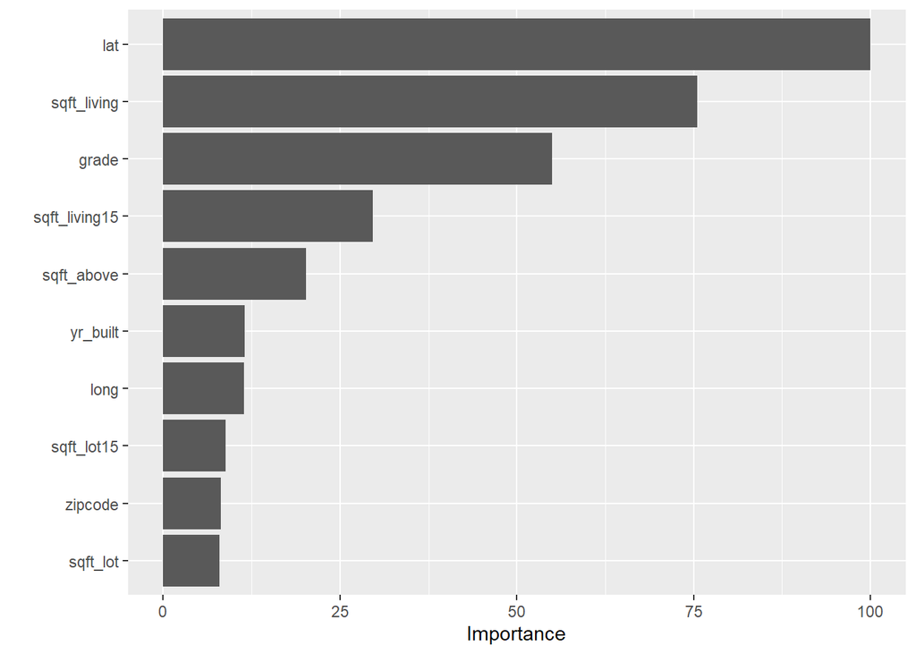

```r
# Random Forest feature importance
rf_importance <- vip(rf_model, num_features = 10)

# Gradient Boosting feature importance
gbm_importance <- vip(gbm_model, num_features = 10)


# Display importance
rf_importance
```

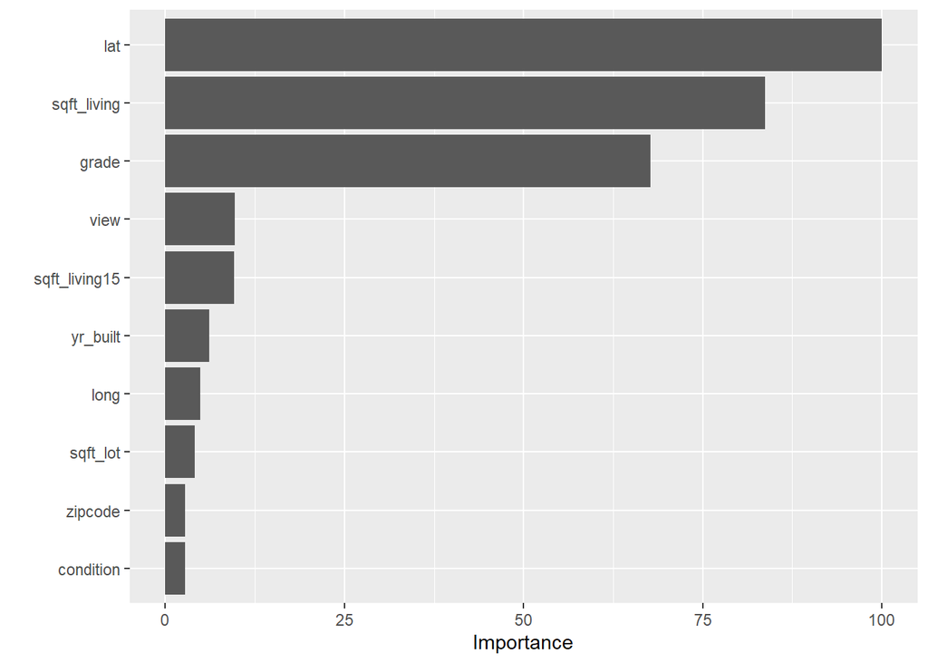

```r
gbm_importance
```

Consistent features: Across all models, lat, sqft_living, grade, and sqft_living15 were repeatedly identified as top predictors, indicating their strong relationship with house prices.

#### Comparison of Methods

The models were evaluated using RMSE (Root Mean Squared Error) on the test set. Lower RMSE values indicate better performance.

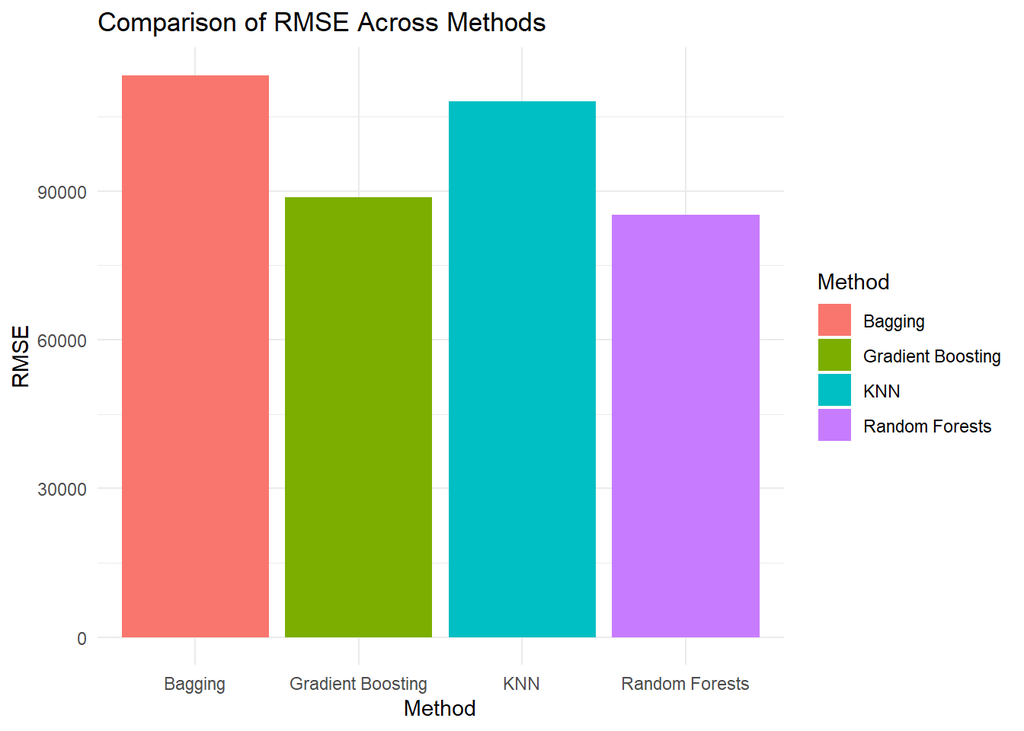

```r
rmse_df <- data.frame(
  Method = c("Bagging", "Random Forests", "Gradient Boosting","KNN"),
  RMSE = c(bagging_rmse, rf_rmse, gbm_rmse,knn_rmse)
)

ggplot(rmse_df, aes(x = Method, y = RMSE, fill = Method)) +
  geom_bar(stat = "identity") +
  labs(title = "Comparison of RMSE Across Methods", x = "Method", y = "RMSE") +
  theme_minimal()
```

Random Forests and Gradient Boosting offer the best predictive accuracy, making them more suitable for predicting house prices in this case.

#### Model Interpretation and Comparison

##### Model Comparison

1. KNN (k-Nearest Neighbors):
- Strengths: Simple, non-parametric (meaning no assumptions about the underlying data distribution), works well for smaller datasets.
- Weaknesses: Computationally expensive for large datasets, sensitive to irrelevant features and outliers.

Performance: RMSE showing decent accuracy but not as good as ensemble models.

2. Ensemble Models (Random Forest, Bagging, Gradient Boosting):
- Strengths:
  - Random Forests: Provides an average of many decision trees to reduce overfitting and improve generalization. It’s robust to overfitting and works well for both regression and classification problems.
  - Bagging: Uses multiple models (decision trees) to create an aggregate prediction, reducing variance but can still suffer from overfitting if the base models are too complex.
  - Gradient Boosting: Uses boosting to iteratively correct the errors of weaker models, making it highly effective in terms of predictive power. It is usually the most accurate of the tree-based models but can be prone to overfitting if not tuned properly.
- Weaknesses:
  - Random Forests and Bagging: While they handle large datasets and high-dimensional spaces well, they may still require a lot of computational resources, especially if the dataset is very large.
  - Gradient Boosting: More computationally expensive and sensitive to hyperparameter tuning. It can overfit if not carefully optimized.

Performance: Random Forest and Gradient Boosting outperformed KNN, showing better accuracy.

##### Interpretation and Discussion

Clustering in KNN: KNN works by finding the closest neighbors to a data point, which essentially means grouping similar data points together. This clustering approach is useful in many scenarios but may not always capture the complex relationships between features in high-dimensional data. In this case, KNN did not perform as well as the ensemble models, indicating that clustering alone was insufficient for capturing the complexities of predicting house prices.

Prediction Accuracy: Ensemble models, particularly Random Forests and Gradient Boosting, performed better in terms of RMSE, showing that they are more effective for predictive modeling tasks involving multiple complex features like those in the house price dataset. These models benefit from their ability to combine predictions from multiple trees, which improves overall accuracy.